# HW3

xw-zeng

2022-10-18

# 合租模式下的租房价格分析

安装并载入R程序包。不过大部分包其实不是必要的，只是为了让输出格式和图像变得好看一点~

```r
##install.packages('DT')
##install.packages('gtsummary')
##install.packages('ggplot2')
##install.packages('dplyr')
##install.packages('sjPlot')
##install.packages('forestmodel')
##install.packages('ggResidpanel')
library(DT) ##预览表格数据
library(gtsummary) ##输出格式比较好看的对定性变量数据的汇总统计包
library(ggplot2) ##可视化好看
library(dplyr) ##数据清洗
library(sjPlot) ##输出格式比较好看的回归模型summary包
library(forestmodel) ##绘制森林图
library(ggResidpanel) ##基于ggplot2绘制回归诊断图
library(car) ##求方差膨胀因子
```

## 分析任务1

读取数据，修改列名为中文，查看数据。

```r
data <- read.csv('data.csv')
colnames(data) <- c('月租金', '卧室数', '厅数', '卫生间数', '租赁房间面积', '租赁房间类型', '所在楼层', '邻近地铁', '所在城区', '供暖方式')
DT::datatable(data)
```

|  | 月租金 | 卧室数 | 厅数 | 卫生间数 | 租赁房间面积 | 租赁房间类型 | 所在楼层 | 邻近地铁 | 所在城区 | 供暖方式 |
| --- | --- | --- | --- | --- | --- | --- | --- | --- | --- | --- |
| 1 | 2730 | 2 | 1 | 1 | 12 | 主卧 | 高楼层 | 是 | 通州 | 集中供暖 |
| 2 | 2740 | 3 | 1 | 1 | 9 | 次卧 | 低楼层 | 是 | 昌平 | 集中供暖 |
| 3 | 2810 | 3 | 1 | 1 | 14 | 主卧 | 低楼层 | 是 | 丰台 | 集中供暖 |
| 4 | 2650 | 4 | 1 | 1 | 8 | 次卧 | 低楼层 | 是 | 丰台 | 集中供暖 |
| 5 | 2670 | 4 | 1 | 1 | 13 | 主卧 | 高楼层 | 否 | 丰台 | 集中供暖 |
| 6 | 2530 | 3 | 1 | 1 | 12 | 次卧 | 高楼层 | 是 | 顺义 | 集中供暖 |
| 7 | 2000 | 2 | 1 | 1 | 10 | 次卧 | 高楼层 | 是 | 大兴 | 集中供暖 |
| 8 | 2780 | 4 | 1 | 1 | 13 | 主卧 | 中楼层 | 是 | 朝阳 | 集中供暖 |
| 9 | 2790 | 4 | 1 | 1 | 10 | 次卧 | 低楼层 | 是 | 昌平 | 集中供暖 |
| 10 | 2640 | 4 | 1 | 1 | 13 | 主卧 | 中楼层 | 是 | 昌平 | 集中供暖 |

[output cut: 5139 more lines]

将定性变量的数据类型更改为因子型(factor)。

```r
for (i in 6:10){data[, i] <- as.factor(data[, i])}
```

汇总统计5个定量变量(最小值、下四分位数、中位数、平均数、上四分位数、最大值)。

```r
summary(data[, 1:5])
```

```
##      月租金         卧室数           厅数         卫生间数      租赁房间面积
##  Min.   :1150   Min.   :2.000   Min.   :1.00   Min.   :1.000   Min.   : 5.00
##  1st Qu.:2240   1st Qu.:2.000   1st Qu.:1.00   1st Qu.:1.000   1st Qu.:10.00
##  Median :2690   Median :3.000   Median :1.00   Median :1.000   Median :12.00
##  Mean   :2798   Mean   :2.996   Mean   :1.01   Mean   :1.027   Mean   :12.85
##  3rd Qu.:3230   3rd Qu.:4.000   3rd Qu.:1.00   3rd Qu.:1.000   3rd Qu.:15.00
##  Max.   :6460   Max.   :5.000   Max.   :2.00   Max.   :2.000   Max.   :30.00
```

汇总统计5个定性变量。

```r
tbl_summary(data[, 6:10])
```

| **Characteristic** | **N = 5,149**<sup>1</sup> |
| --- | --- |
| 租赁房间类型 |  |
| 次卧 | 2,860 (56%) |
| 主卧 | 2,289 (44%) |
| 所在楼层 |  |
| 低楼层 | 1,679 (33%) |
| 高楼层 | 1,592 (31%) |
| 中楼层 | 1,878 (36%) |
| 邻近地铁 |  |
| 否 | 815 (16%) |
| 是 | 4,334 (84%) |
| 所在城区 |  |
| 昌平 | 702 (14%) |
| 朝阳 | 1,317 (26%) |
| 大兴 | 361 (7.0%) |
| 东城 | 94 (1.8%) |
| 房山 | 183 (3.6%) |
| 丰台 | 581 (11%) |
| 海淀 | 424 (8.2%) |
| 石景山 | 258 (5.0%) |
| 顺义 | 314 (6.1%) |
| 通州 | 819 (16%) |
| 西城 | 96 (1.9%) |
| 供暖方式 |  |
| 集中供暖 | 4,197 (82%) |
| 自采暖 | 952 (18%) |

<sup>1</sup> n (%)

## 分析任务2

绘制总体数据中月租金(rent)的直方图。

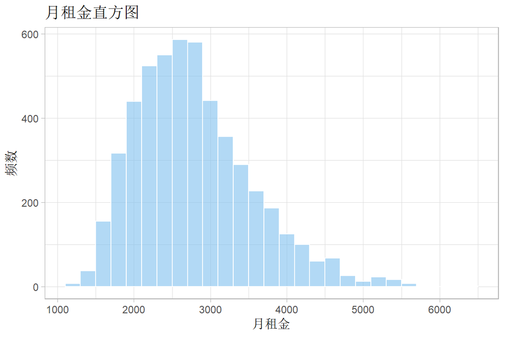

```r
ggplot(data = data,mapping = aes(x = 月租金)) +
  geom_histogram(color = 'white', fill = 'skyblue2', binwidth = 200,
                 mapping = aes(y = ..count..), alpha = 0.6) +
  labs(title = '月租金直方图', y = '频数') +
  theme_light()
```

由直方图可知，基本所有房源的月租金都处于1500RMB-5000RMB之间。月租金的分布大致为**右偏分布**，即月租金的中位数2690小于其平均值2798，这说明中低月租(2000RMB-3000RMB)的房源较多，高月租的房源较少。

## 分析任务3

计算不同城区(region)租房平均价格。

```r
##把数据按照所在城区分组，分别统计对应城区的月租金的平均数。
rent_mean <- data %>% group_by(所在城区) %>% summarise('平均租金' = mean(月租金))
##把新生成的数据按照平均租金降序排列，便于后续数据可视化。
rent_mean <- rent_mean[order(rent_mean$平均租金, decreasing = TRUE), ]
```

选取平均租金最高的8个城区，绘制降序平均租金柱状图。

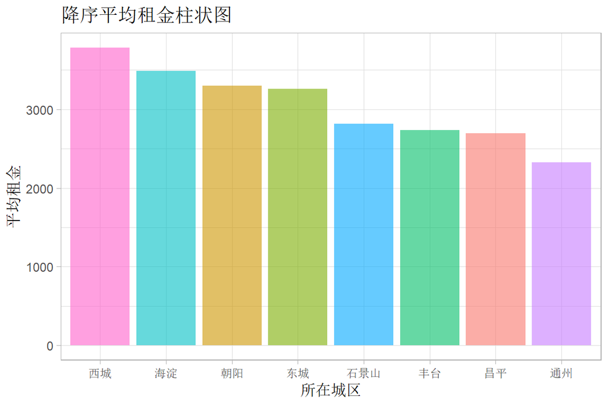

```r
ggplot(rent_mean[1:8, ], mapping = aes(x = 所在城区, y = 平均租金, fill = 所在城区)) +
  geom_bar(stat = 'identity', alpha = 0.6) +
  scale_x_discrete(limits = rent_mean$所在城区[1:8]) +
  labs(title = '降序平均租金柱状图') +
  guides(fill = 'none') +
  theme_light()
```

## 分析任务4

绘制月租金(rent)-城区(region)分组箱线图。

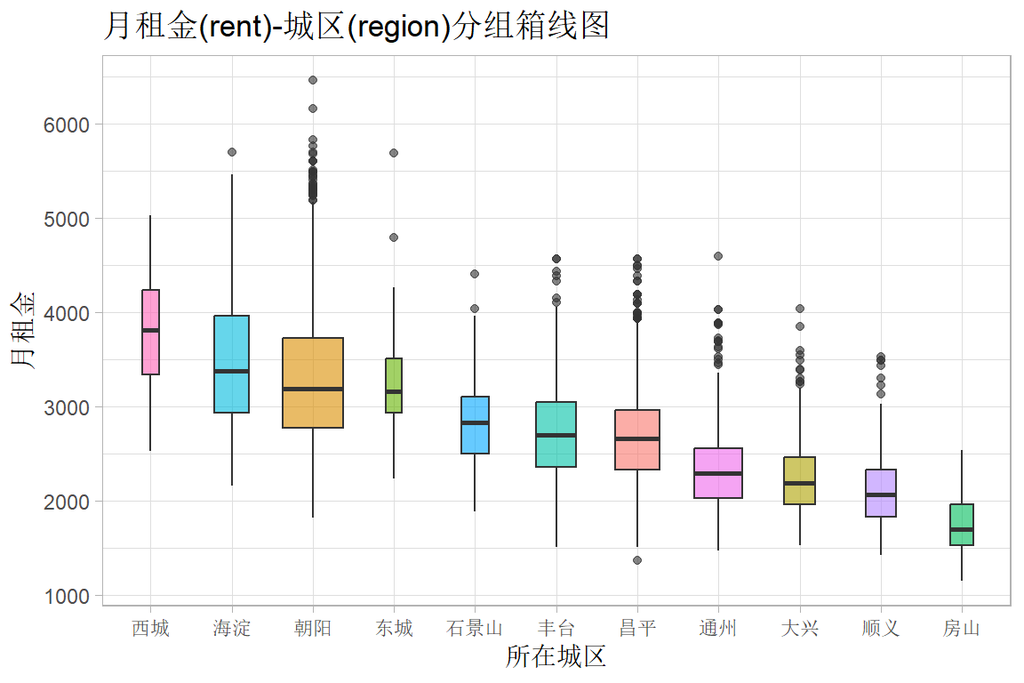

```r
ggplot(data, mapping = aes(x = 所在城区, y = 月租金, fill = 所在城区)) +
  geom_boxplot(varwidth = TRUE, alpha = 0.6) +
  scale_x_discrete(limits = rent_mean$所在城区) +
  labs(title = '月租金(rent)-城区(region)分组箱线图') +
  guides(fill = 'none') +
  theme_light()
```

从这张分组箱线图中我们可以得到和**分析任务3**基本相同的结论：中心城区的月租金比偏远城区的月租金高。如果按照月租金高低对11个城区进行划分，则西城、海淀、朝阳、东城属于第一梯度，月租金最高；石景山、丰台、昌平属于第二梯度；通州、大兴、顺义属于第三梯度；房山属于第四梯度，月租金最低。这四个梯度的月租金的**组内差异较小**，**组间差异较大**。另外，与上个任务不同的是，这里的比较标准是每个城区的**中位数**(即箱体中间的横线高低)。

从上图我们还能得出其他相关的信息。每个箱体的宽度表示每个城区的样本量大小，朝阳区的房源最多，其次是通州、昌平、丰台等城区，而西城、东城、房山的房源最少。大部分城区都有离群值存在(即小于下四分位数-1.5*四分位间距，或大于上四分位数+1.5*四分位间距)，且大部分都为高于上四分位数+1.5*四分位间距的离群点，这说明即使条件和地理位置再不好，也极少出现租金特别低的情况。这些离群点存在的原因可能是除了所在城区这一变量之外，还存在着其他对月租金有显著影响的因素，因此我们需要建立线性回归模型进行研究。

## 分析任务5

为因子类型指定基准组。

- 租赁房间变量以“次卧”作为基准组。
- 所在楼层变量以“低楼层”作为基准组。
- 邻近地铁变量以“否”作为基准组。
- 所在城区变量以“石景山”作为基准组。
- 供暖方式变量以“自采暖”作为基准组。

```r
data <- data %>%
  mutate(租赁房间类型 = relevel(租赁房间类型, ref = '次卧'),
         所在楼层 = relevel(所在楼层, ref = '低楼层'),
         邻近地铁 = relevel(邻近地铁, ref = '否'),
         所在城区 = relevel(所在城区, ref = '石景山'),
         供暖方式 = relevel(供暖方式, ref = '自采暖'))
```

将数据集按照8:2的比例，划分为训练集和测试集。

```r
set.seed(2022)
##随机生成训练集的索引。
idx_train <- sample(1:nrow(data), 0.8 * nrow(data))
##划分训练集和测试集。
data_train <- data[idx_train, ]
data_test <- data[-idx_train, ]
```

使用训练集数据建立以月租金(rent)为因变量，其余为自变量的线性回归模型。

```r
fit <- lm(月租金~., data_train)
##生成回归系数表(对回归系数、标准误、t value都近似至三位小数)。
tab_model(fit, show.ci = FALSE, show.se = TRUE, show.stat = TRUE, digits = 3, digits.rsq = 4, p.style = 'numeric_stars', string.pred = 'Coefficients', string.se = 'Std. Error', string.stat = 't value', string.p = 'Pr(>|t|)', title = '回归系数表')
```

回归系数表

月租金

Coefficients

Estimates

Std. Error

t value

Pr(>|t|)

(Intercept)

1617.036 ***

92.524

17.477

**<0.001**

卧室数

-91.560 ***

9.849

-9.296

**<0.001**

厅数

-220.867 **

82.350

-2.682

**0.007**

卫生间数

197.590 ***

49.443

3.996

**<0.001**

租赁房间面积

78.267 ***

2.180

35.900

**<0.001**

租赁房间类型 [主卧]

-6.573

18.450

-0.356

0.722

所在楼层 [高楼层]

-28.494

17.984

-1.584

0.113

所在楼层 [中楼层]

-62.634 ***

17.143

-3.654

**<0.001**

邻近地铁 [是]

274.824 ***

19.609

14.015

**<0.001**

所在城区 [昌平]

63.522

38.212

1.662

0.097

所在城区 [朝阳]

649.852 ***

35.512

18.300

**<0.001**

所在城区 [大兴]

-411.933 ***

41.776

-9.860

**<0.001**

所在城区 [东城]

538.684 ***

61.744

8.724

**<0.001**

所在城区 [房山]

-801.056 ***

50.578

-15.838

**<0.001**

所在城区 [丰台]

126.444 **

39.054

3.238

**0.001**

所在城区 [海淀]

903.310 ***

41.172

21.940

**<0.001**

所在城区 [顺义]

-461.238 ***

43.783

-10.535

**<0.001**

所在城区 [通州]

-367.739 ***

36.656

-10.032

**<0.001**

所在城区 [西城]

955.806 ***

60.032

15.922

**<0.001**

供暖方式 [集中供暖]

158.917 ***

19.319

8.226

**<0.001**

Observations

4119

R<sup>2</sup> / R<sup>2</sup> adjusted

0.6534 / 0.6518

- p<0.05 ** p<0.01 *** p<0.001

因为该模型中存在通过t检验的回归系数，故该模型一定通过F检验。调整后R方为0.6518，说明月租金的波动有65.18%可以被模型中的自变量解释。

绘制该回归模型的森林图，以清晰直观地观察回归模型中的系数。

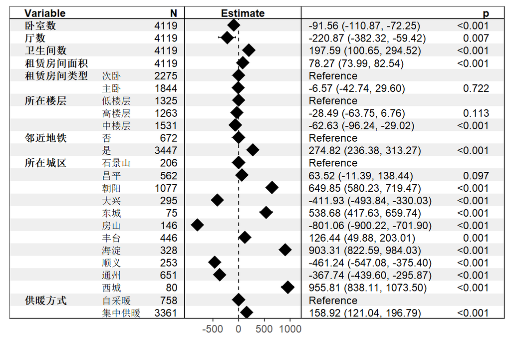

```r
forest_model(fit, format_options = forest_model_format_options(shape = 18, point_size = 5))
```

以0.05作为显著性水平，简单观察后发现，定量变量在模型中的回归系数全部具有显著性。卧室数、厅数对月租金有显著负向影响，而卫生间数、租赁房间面积对月租金有显著正向影响。这与我们的常识相符。因为房源卧室数、厅数更多，代表客户要和更多人同住屋檐下，住房体验更差；卫生间数更多、租赁房间面积更大，代表客户的生活空间更自由，住房体验更好，自然月租金价格更高。

讨论完了定量变量，我们来看定性变量。

- 租赁房间的类型对月租金没有显著影响，我猜想这是因为该变量被租赁房间面积解释了，根据常识，主卧的房间面积应该大于次卧的房间面积。
- 中楼层的月租金比低楼层的月租金显著要低，但高楼层与低楼层却没有显著差异。这可能是因为中楼层爬楼梯很累、房源不一定有电梯，客户住房体验差；低楼层和高楼层则较为方便客户(低楼层爬楼梯轻松、高楼层的楼栋一般都有电梯)，月租金价格更高。
- 邻近地铁的房源的月租金比不邻近地铁的显著要高，这是因为四周交通便利的房源更方便客户通勤和生活。是否邻近地铁的回归系数绝对值较大(274.82)，是月租金的重要影响因素。
- 所在城区以石景山作为基准组，朝阳、东城、丰台、海淀、西城的月租金比石景山显著要高，昌平与石景山没有显著差异，大兴、房山、顺义、通州的月租金比石景山显著要低。由森林图可知所在城区大部分哑变量的回归系数的绝对值都很大(偏离中线幅度较大)，故房源的地理位置是影响月租金的重要因素。
- 供暖方式为集中供暖的房源月租金比自采暖的显著要高。

现在对线性回归模型的结果进行解读。**当控制其他因素不变时：**

- **卧室数**每增加1个，月租金平均降低91.56元。
- **厅数**每增加1个，月租金平均降低220.87元。
- **卫生间数**每增加1个，月租金平均增加197.59元。
- **租赁房间面积**每增加1平方米，月租金平均增加78.27元。
- **租赁房间类型**：主卧与次卧的月租金没有显著差异。
- **所在楼层**：中楼层比低楼层的月租金平均低了62.63元，高楼层与低楼层的月租金没有显著差异。
- **邻近地铁**：邻近地铁比不邻近地铁的房源月租金平均高了274.82元。
- **所在城区**：以石景山作为基准组，昌平与石景山的月租金没有显著差异；朝阳、东城、丰台、海淀、西城比石景山的月租金分别平均高了649.85元、538.68元、126.44元、903.31元、955.81元；大兴、房山、顺义、通州比石景山的月租金分别平均低了411.93元、801.06元、461.24元、367.74元。
- **供暖方式**：供暖方式为集中供暖的房源比自采暖的房源月租金平均高了158.92元。

## 分析任务6

对上面的回归模型利用BIC准则进行变量选择。

```r
##stepwise-selection
step(fit, direction = 'both', k = log(nrow(data_train)))
```

```
## Start:  AIC=50571.06
## 月租金 ~ 卧室数 + 厅数 + 卫生间数 + 租赁房间面积 +
##     租赁房间类型 + 所在楼层 + 邻近地铁 + 所在城区 +
##     供暖方式
##
##                Df Sum of Sq        RSS   AIC
## - 租赁房间类型  1     26309  849783493 50563
## - 所在楼层      2   2790382  852547566 50568
## - 厅数          1   1491244  851248428 50570
## <none>                       849757184 50571
## - 卫生间数      1   3310819  853068003 50579
## - 供暖方式      1  14028379  863785563 50630
## - 卧室数        1  17915576  867672760 50649
## - 邻近地铁      1  40718897  890476081 50756
## - 租赁房间面积  1 267186542 1116943726 51689
## - 所在城区     10 993025258 1842782442 53676
##
## Step:  AIC=50562.87
## 月租金 ~ 卧室数 + 厅数 + 卫生间数 + 租赁房间面积 +
##     所在楼层 + 邻近地铁 + 所在城区 + 供暖方式
##
##                Df Sum of Sq        RSS   AIC
## - 所在楼层      2   2784395  852567888 50560
## - 厅数          1   1484754  851268247 50562
## <none>                       849783493 50563
## - 卫生间数      1   3328857  853112350 50571
## + 租赁房间类型  1     26309  849757184 50571
## - 供暖方式      1  14033470  863816963 50622
## - 卧室数        1  18409008  868192501 50643
## - 邻近地铁      1  40887795  890671288 50748
## - 租赁房间面积  1 428333407 1278116900 52236
## - 所在城区     10 997691028 1847474521 53678
##
## Step:  AIC=50559.7
## 月租金 ~ 卧室数 + 厅数 + 卫生间数 + 租赁房间面积 +
##     邻近地铁 + 所在城区 + 供暖方式
##
##                Df Sum of Sq        RSS   AIC
## - 厅数          1   1431746  853999634 50558
## <none>                       852567888 50560
```

[output cut: 9 more lines]

```
## Step:  AIC=50558.28
## 月租金 ~ 卧室数 + 卫生间数 + 租赁房间面积 + 邻近地铁 +
##     所在城区 + 供暖方式
##
##                Df  Sum of Sq        RSS   AIC
## <none>                        853999634 50558
## + 厅数          1    1431746  852567888 50560
## - 卫生间数      1    2130581  856130215 50560
## + 所在楼层      2    2731387  851268247 50562
## + 租赁房间类型  1      15109  853984525 50567
## - 供暖方式      1   13680451  867680085 50615
## - 卧室数        1   19112093  873111727 50641
## - 邻近地铁      1   41183186  895182820 50744
## - 租赁房间面积  1  427059219 1281058853 52220
## - 所在城区     10 1000825293 1854824927 53670
```

```
##
## Call:
## lm(formula = 月租金 ~ 卧室数 + 卫生间数 + 租赁房间面积 +
##     邻近地铁 + 所在城区 + 供暖方式, data = data_train)
##
## Coefficients:
##      (Intercept)            卧室数          卫生间数      租赁房间面积
##          1418.08            -92.21            149.37             77.63
##       邻近地铁是      所在城区昌平      所在城区朝阳      所在城区大兴
##           276.09             66.22            653.35           -409.61
##     所在城区东城      所在城区房山      所在城区丰台      所在城区海淀
##           541.40           -799.40            127.41            903.82
##     所在城区顺义      所在城区通州      所在城区西城  供暖方式集中供暖
##          -467.38           -366.95            952.20            156.85
```

虽然上面步骤中显示的仍然是AIC，但我已经通过把`step`中的参数`k`(模型自变量个数$d$的惩罚系数)修改为$logN$，其中$N$为数据集中的样本个数，故此时的变量选择准则就是**BIC准则**。

$$AIC = -{\frac 2 N}L(\beta)+2{\frac d N}\\
BIC = -2L(\beta)+(logN)d$$

使用逐步选择(stepwise-selection，对应`step`中的参数`direction`=‘both’)的变量选择方法，以BIC信息准则作为判断标准，最终模型中留下的自变量为：卧室数、卫生间数、租赁房间面积、邻近地铁、所在城区、供暖方式。以这些变量作为自变量，使用训练集的数据建立新的线性回归模型。

```r
##删除厅数、租赁房间类型、所在楼层这三个变量(分别对应数据的第3、6、7列)，建立线性回归模型。
fit <- lm(月租金~., data_train[, -c(3, 6, 7)])
##生成回归系数表(对回归系数、标准误、t value都近似至三位小数)。
tab_model(fit, show.ci = FALSE, show.se = TRUE, show.stat = TRUE, digits = 3, digits.rsq = 4, p.style = 'numeric_stars', string.pred = 'Coefficients', string.se = 'Std. Error', string.stat = 't value', string.p = 'Pr(>|t|)', title = '使用BIC准则进行变量选择后的回归系数表')
```

使用BIC准则进行变量选择后的回归系数表

月租金

Coefficients

Estimates

Std. Error

t value

Pr(>|t|)

(Intercept)

1418.079 ***

67.429

21.031

**<0.001**

卧室数

-92.208 ***

9.623

-9.582

**<0.001**

卫生间数

149.368 **

46.686

3.199

**0.001**

租赁房间面积

77.631 ***

1.714

45.297

**<0.001**

邻近地铁 [是]

276.091 ***

19.628

14.066

**<0.001**

所在城区 [昌平]

66.219

38.275

1.730

0.084

所在城区 [朝阳]

653.352 ***

35.566

18.370

**<0.001**

所在城区 [大兴]

-409.612 ***

41.801

-9.799

**<0.001**

所在城区 [东城]

541.400 ***

61.852

8.753

**<0.001**

所在城区 [房山]

-799.396 ***

50.621

-15.792

**<0.001**

所在城区 [丰台]

127.406 **

39.119

3.257

**0.001**

所在城区 [海淀]

903.820 ***

41.242

21.915

**<0.001**

所在城区 [顺义]

-467.381 ***

43.771

-10.678

**<0.001**

所在城区 [通州]

-366.945 ***

36.715

-9.994

**<0.001**

所在城区 [西城]

952.196 ***

60.118

15.839

**<0.001**

供暖方式 [集中供暖]

156.848 ***

19.347

8.107

**<0.001**

Observations

4119

R<sup>2</sup> / R<sup>2</sup> adjusted

0.6517 / 0.6504

- p<0.05 ** p<0.01 *** p<0.001

减少了3个自变量(厅数、租赁房间类型、所在楼层)后，新的回归模型调整后R方为0.6504，只比上一个回归模型的调整后R方低了0.0014，说明**变量选择过程基本没有带来信息损失**。新的模型回归系数(除了所在城区中的昌平在0.1显著性水平下显著，不在0.05显著性水平下显著)都通过了t检验，回归模型一定通过F检验，说明模型效果很好。

现在对新线性回归模型的结果进行解读。**当控制其他因素不变时：**

- **卧室数**每增加1个，月租金平均降低92.21元。
- **卫生间数**每增加1个，月租金平均增加149.37元。
- **租赁房间面积**每增加1平方米，月租金平均增加77.63元。
- **邻近地铁**：邻近地铁比不邻近地铁的房源月租金平均高了276.09元。
- **所在城区**：以石景山作为基准组，昌平与石景山的月租金没有显著差异；朝阳、东城、丰台、海淀、西城比石景山的月租金分别平均高了653.35元、541.40元、127.41元、903.82元、952.20元；大兴、房山、顺义、通州比石景山的月租金分别平均低了409.61元、799.40元、467.38元、366.95元。
- **供暖方式**：供暖方式为集中供暖的房源比自采暖的房源月租金平均高了156.85元。

## 分析任务7

定义$k$折交叉验证的函数。

```r
cross_valid <- function(df, k){
  ##给每个样本编号。
  idx <- sample(1:k, nrow(df), replace = TRUE)
  rmse_train <- c()
  rmse_test <- c()
  ##循环k次。
  for (i in 1:k){
    ##根据编号将数据集划分为训练集和测试集。
    data_train <- df[idx != i, ]
    data_test <- df[idx == i, ]
    ##用训练集训练线性回归模型。
    fit <- lm(月租金~., data_train)
    ##用拟合出的模型在测试集上做预测。
    pred <- predict(fit, data_test)
    ##计算RMSE(均方根误差)。
    rmse_train <- c(rmse_train, sqrt(mean((fit$fitted.values - data_train$月租金) ^ 2)))
    rmse_test <- c(rmse_test, sqrt(mean((pred - data_test$月租金) ^ 2)))
  }
  ##返回k个模型在训练集上的RMSE和在测试集上的RMSE。
  structure(list(rmse_train = rmse_train, rmse_test = rmse_test))
}
```

对BIC选择后的模型重复进行50次的五折交叉验证，以减少抽样误差。

```r
rmse <- c()
rmse_df <- data.frame('time' = NA, 'type' = NA, 'rmse' = NA)
##设置随机数种子，使结果可重复
set.seed(1)
for (j in 1:50){
  result <- cross_valid(data[, -c(3, 6, 7)], 5)
  ##收集每次五折交叉验证中RMSE分别在训练集和测试集上的值
  rmse_df <- rbind(na.omit(rmse_df), data.frame('time' = (j - 1) * 5 + rep(1:5, 2), 'type' = c(rep('训练集', 5), rep('测试集', 5)), 'rmse' = c(result[[1]], result[[2]])))
}
##分别计算训练集和测试集上250个RMSE的均值
rmse_train_mean <- mean(rmse_df$rmse[which(rmse_df$type == '训练集')])
rmse_test_mean <- mean(rmse_df$rmse[which(rmse_df$type == '测试集')])
print(paste('50次五折交叉验证的训练集的RMSE均值为', rmse_train_mean, '。', sep = '')); print(paste('50次五折交叉验证的测试集的RMSE均值为', rmse_test_mean, '。', sep = ''))
```

```
## [1] "50次五折交叉验证的训练集的RMSE均值为453.820739891688。"
```

```
## [1] "50次五折交叉验证的测试集的RMSE均值为455.360066710828。"
```

BIC选择后的模型在**测试集**上的RMSE均值约为455.36，和**训练集**453.82相差不大，似乎预测效果还是不错的。但是均值并不能反映数据的所有信息，故再通过作图查看二者差异。

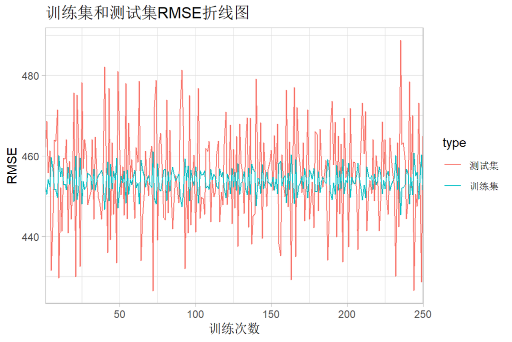

```r
ggplot(rmse_df, mapping = aes(x = time, y = rmse, color = type)) +
  geom_line() + scale_x_continuous(expand = c(0, 0)) +
  labs(title = '训练集和测试集RMSE折线图', x = '训练次数', y = 'RMSE') +
  theme_light()
```

由图可知，测试集和训练集的RMSE的均值相差不大，但是测试集RMSE的波动幅度明显高于训练集RMSE，可见该线性模型的预测稳定性仍有待提高。

## 模型诊断

最后对BIC选择后的回归模型进行回归诊断。

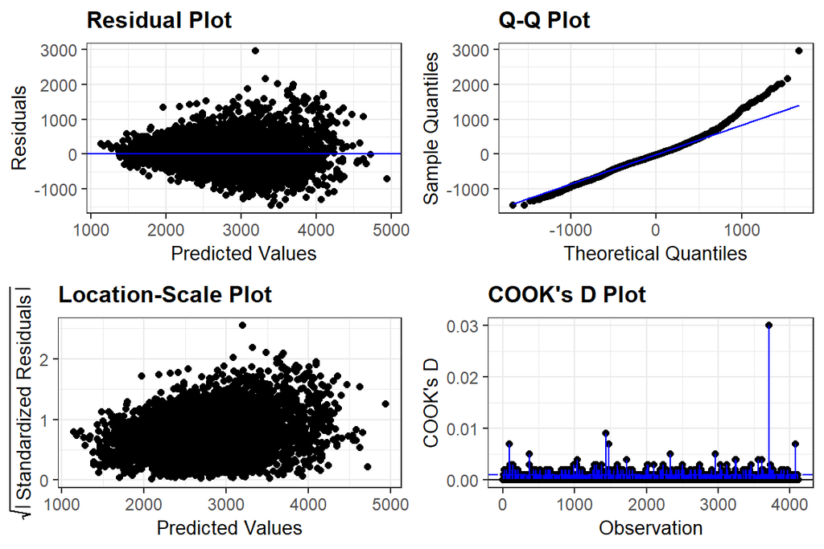

```r
resid_panel(fit, plots = c('resid', 'qq', 'ls', 'cookd'))
```

由residual plot可知，残差与因变量大小无关，都在0上下波动，两侧分布均匀。但是location-scale plot中显示出随着因变量月租金的增加，残差的方差也在增加，存在**异方差**的问题。Q-Q plot说明了残差**不服从正态分布**，右侧实际的分位数明显高于理论的分位数。Cook’s D plot说明数据中没有很明显的离群值。

对于回归诊断出的这些问题，可以通过对因变量(月租金)**取对数**来改善。

检查模型是否存在多重共线性问题。

```r
vif(fit)
```

```
##                  GVIF Df GVIF^(1/(2*Df))
## 卧室数       1.159813  1        1.076946
## 卫生间数     1.051609  1        1.025480
## 租赁房间面积 1.017708  1        1.008815
## 邻近地铁     1.040884  1        1.020237
## 所在城区     1.237569 10        1.010714
## 供暖方式     1.112252  1        1.054634
```

方差膨胀因子VIF都在1左右，非常小，说明模型不存在多重共线性问题，这是因为先前变量选择的操作能够很好地规避该问题。